# SAP - Projekt - Analiza teniskih mečeva

Benjak Petar, Bilić Ante, Kaštelan Niko, Paradžik Mario

## Motivacija i opis problema

Statistika i predviđanje sportskih rezultata mogu pomoći menadžerima, trenerima, procjeniteljima kvota i drugima u donošenju odluka. U tenisu je statistika kao alat dobila dodatnu popularnost zahvaljujući bivšem treneru Craigu O’Shaughnessyu, strategu s uporištem u statistici čija je analiza bila ključna u rezultatima Novaka Đokovića protiv njegovih najvećih rivala. Svojim zaključcima izvedenim iz povijesnih podataka mečeva tenisačima je moguće prilagoditi kondicijske pripreme, teniske treninge i strategiju protiv pojedinih protivnika, što rezultira boljom i konzistentnijom igrom.

### Učitavanje potrebnih paketa

```r
library(dplyr)
library(tidyverse)
```

### Učitavanje podataka

```r
tennisMatches = read.csv('tennis_atp_matches.csv')
```

### Dimenzija podataka

```r
dim(tennisMatches)
```

```
## [1] 96602    50
```

### Nazivi varijabli

```r
names(tennisMatches)
```

```
##  [1] "X"                  "tourney_id"         "tourney_name"
##  [4] "surface"            "draw_size"          "tourney_level"
##  [7] "tourney_date"       "match_num"          "winner_id"
## [10] "winner_seed"        "winner_entry"       "winner_name"
## [13] "winner_hand"        "winner_ht"          "winner_ioc"
## [16] "winner_age"         "loser_id"           "loser_seed"
## [19] "loser_entry"        "loser_name"         "loser_hand"
## [22] "loser_ht"           "loser_ioc"          "loser_age"
## [25] "score"              "best_of"            "round"
## [28] "minutes"            "w_ace"              "w_df"
## [31] "w_svpt"             "w_1stIn"            "w_1stWon"
## [34] "w_2ndWon"           "w_SvGms"            "w_bpSaved"
## [37] "w_bpFaced"          "l_ace"              "l_df"
## [40] "l_svpt"             "l_1stIn"            "l_1stWon"
## [43] "l_2ndWon"           "l_SvGms"            "l_bpSaved"
## [46] "l_bpFaced"          "winner_rank"        "winner_rank_points"
## [49] "loser_rank"         "loser_rank_points"
```

### Prikaz podataka

```r
View(tennisMatches)
```

### Tipovi varijabli u skupu podataka

```r
sapply(tennisMatches, class)
```

```
##                  X         tourney_id       tourney_name            surface
##          "integer"           "factor"           "factor"           "factor"
##          draw_size      tourney_level       tourney_date          match_num
##          "integer"           "factor"          "integer"          "integer"
##          winner_id        winner_seed       winner_entry        winner_name
##          "integer"          "numeric"           "factor"           "factor"
##        winner_hand          winner_ht         winner_ioc         winner_age
##           "factor"          "numeric"           "factor"          "numeric"
##           loser_id         loser_seed        loser_entry         loser_name
##          "integer"          "numeric"           "factor"           "factor"
##         loser_hand           loser_ht          loser_ioc          loser_age
##           "factor"          "numeric"           "factor"          "numeric"
##              score            best_of              round            minutes
##           "factor"          "integer"           "factor"          "numeric"
##              w_ace               w_df             w_svpt            w_1stIn
##          "numeric"          "numeric"          "numeric"          "numeric"
##           w_1stWon           w_2ndWon            w_SvGms          w_bpSaved
##          "numeric"          "numeric"          "numeric"          "numeric"
##          w_bpFaced              l_ace               l_df             l_svpt
##          "numeric"          "numeric"          "numeric"          "numeric"
##            l_1stIn           l_1stWon           l_2ndWon            l_SvGms
##          "numeric"          "numeric"          "numeric"          "numeric"
##          l_bpSaved          l_bpFaced        winner_rank winner_rank_points
##          "numeric"          "numeric"          "numeric"          "numeric"
##         loser_rank  loser_rank_points
##          "numeric"          "numeric"
```

Kod učitavanja podataka može doći do situacije gdje se tipovi podatak pogrešno prepoznaju pa ih je potrebno ručno izmijeniti. U ovom se slučaju krivo prepoznaju tipovi varijabli: tourney_date, winner_id te loser_id.

```r
tennisMatches = tennisMatches %>% mutate(tourney_date = as.Date(as.character(tourney_date), "%Y%m%d"),
                  winner_id = as.factor(winner_id),
                  loser_id = as.factor(loser_id))
```

```r
summary(tennisMatches)
```

```
##        X            tourney_id                  tourney_name     surface
##  Min.   :    0   1991-520:  127   Australian Open     : 3810         :  198
##  1st Qu.:24150   1991-540:  127   Roland Garros       : 3810   Carpet: 7215
##  Median :48300   1991-560:  127   US Open             : 3683   Clay  :32395
##  Mean   :48300   1991-580:  127   Wimbledon           : 3683   Grass : 9250
##  3rd Qu.:72451   1992-520:  127   Miami Masters       : 2755   Hard  :47544
##  Max.   :96601   1992-540:  127   Indian Wells Masters: 2266
##                  (Other) :95840   (Other)             :76595
##    draw_size      tourney_level  tourney_date          match_num
##  Min.   :  4.00   A:55670       Min.   :1990-12-31   Min.   :   1.00
##  1st Qu.: 32.00   D: 9027       1st Qu.:1997-04-21   1st Qu.:   9.00
##  Median : 32.00   F:  466       Median :2004-06-14   Median :  22.00
##  Mean   : 52.75   G:15113       Mean   :2004-10-30   Mean   :  58.42
##  3rd Qu.: 64.00   M:16326       3rd Qu.:2012-02-20   3rd Qu.:  48.00
##  Max.   :128.00                 Max.   :2020-11-16   Max.   :1701.00
##
##    winner_id      winner_seed     winner_entry           winner_name
##  103819 : 1250   Min.   : 1.00          :85146   Roger Federer : 1250
##  104745 : 1012   1st Qu.: 3.00   Q      : 6751   Rafael Nadal  : 1012
##  104925 :  946   Median : 5.00   WC     : 3763   Novak Djokovic:  946
##  103970 :  740   Mean   : 6.85   LL     :  772   David Ferrer  :  740
##  101736 :  692   3rd Qu.: 8.00   PR     :  123   Andre Agassi  :  692
##  101948 :  687   Max.   :35.00   SE     :   43   Pete Sampras  :  687
##  (Other):91275   NA's   :57628   (Other):    4   (Other)       :91275
##  winner_hand   winner_ht       winner_ioc      winner_age       loser_id
##   :   18     Min.   :160.0   ESP    :11394   Min.   :14.35   103852 :  457
##  L:13450     1st Qu.:180.0   USA    :10520   1st Qu.:22.96   104269 :  424
##  R:82512     Median :185.0   FRA    : 7861   Median :25.49   104022 :  423
##  U:  622     Mean   :185.5   GER    : 5785   Mean   :25.74   102148 :  422
##              3rd Qu.:190.0   ARG    : 5078   3rd Qu.:28.24   104312 :  404
##              Max.   :211.0   RUS    : 4064   Max.   :42.79   104259 :  388
##              NA's   :4070    (Other):51900   NA's   :58      (Other):94084
##    loser_seed     loser_entry                    loser_name    loser_hand
##  Min.   : 1.0           :77637   Feliciano Lopez      :  457    :   50
##  1st Qu.: 4.0    Q      :10815   Fernando Verdasco    :  424   L:13809
##  Median : 6.0    WC     : 6503   Mikhail Youzhny      :  423   R:81232
##  Mean   : 8.2    LL     : 1435   Fabrice Santoro      :  422   U: 1511
##  3rd Qu.:11.0    PR     :  145   Andreas Seppi        :  404
##  Max.   :35.0    SE     :   58   Philipp Kohlschreiber:  388
##  NA's   :75349   (Other):    9   (Other)              :94084
```

[output cut: 49 more lines]

```
##  Min.   : 0.000   Min.   :   1.00   Min.   :    1      Min.   :   1.0
##  1st Qu.: 6.000   1st Qu.:  18.00   1st Qu.:  517      1st Qu.:  37.0
##  Median : 8.000   Median :  46.00   Median :  860      Median :  71.0
##  Mean   : 8.752   Mean   :  81.35   Mean   : 1387      Mean   : 119.9
##  3rd Qu.:11.000   3rd Qu.:  89.00   3rd Qu.: 1551      3rd Qu.: 119.0
##  Max.   :35.000   Max.   :2101.00   Max.   :16950      Max.   :2159.0
##  NA's   :9793     NA's   :1040      NA's   :2032       NA's   :2289
##  loser_rank_points
##  Min.   :    1.0
##  1st Qu.:  385.0
##  Median :  639.0
##  Mean   :  867.6
##  3rd Qu.: 1015.0
##  Max.   :16950.0
##  NA's   :3278
```

### Traženje nedostajućih vrijednosti

Dani skup podataka nerijetko sadrži nedostajuće podatke. Rad nad takvim podacima može dovesti do pogrešaka u testiranju hipoteza i zaključivanju. Varijable s velikim udjelom nedostajućih vrijednosti odbacujemo iz skupa podataka.

```r
for (col_name in names(tennisMatches)){
  if (sum(is.na(tennisMatches[,col_name])) > 0){
    cat('Ukupno nedostajućih vrijednosti za varijablu ',col_name, ': ', sum(is.na(tennisMatches[,col_name])),'\n')
  }
}
```

```
## Ukupno nedostajućih vrijednosti za varijablu  winner_seed :  57628
## Ukupno nedostajućih vrijednosti za varijablu  winner_ht :  4070
## Ukupno nedostajućih vrijednosti za varijablu  winner_age :  58
## Ukupno nedostajućih vrijednosti za varijablu  loser_seed :  75349
## Ukupno nedostajućih vrijednosti za varijablu  loser_ht :  7671
## Ukupno nedostajućih vrijednosti za varijablu  loser_age :  127
## Ukupno nedostajućih vrijednosti za varijablu  minutes :  12410
## Ukupno nedostajućih vrijednosti za varijablu  w_ace :  9793
## Ukupno nedostajućih vrijednosti za varijablu  w_df :  9793
## Ukupno nedostajućih vrijednosti za varijablu  w_svpt :  9793
## Ukupno nedostajućih vrijednosti za varijablu  w_1stIn :  9793
## Ukupno nedostajućih vrijednosti za varijablu  w_1stWon :  9793
## Ukupno nedostajućih vrijednosti za varijablu  w_2ndWon :  9793
## Ukupno nedostajućih vrijednosti za varijablu  w_SvGms :  9793
## Ukupno nedostajućih vrijednosti za varijablu  w_bpSaved :  9793
## Ukupno nedostajućih vrijednosti za varijablu  w_bpFaced :  9793
## Ukupno nedostajućih vrijednosti za varijablu  l_ace :  9793
## Ukupno nedostajućih vrijednosti za varijablu  l_df :  9793
## Ukupno nedostajućih vrijednosti za varijablu  l_svpt :  9793
## Ukupno nedostajućih vrijednosti za varijablu  l_1stIn :  9793
## Ukupno nedostajućih vrijednosti za varijablu  l_1stWon :  9793
## Ukupno nedostajućih vrijednosti za varijablu  l_2ndWon :  9793
## Ukupno nedostajućih vrijednosti za varijablu  l_SvGms :  9793
## Ukupno nedostajućih vrijednosti za varijablu  l_bpSaved :  9793
## Ukupno nedostajućih vrijednosti za varijablu  l_bpFaced :  9793
## Ukupno nedostajućih vrijednosti za varijablu  winner_rank :  1040
## Ukupno nedostajućih vrijednosti za varijablu  winner_rank_points :  2032
## Ukupno nedostajućih vrijednosti za varijablu  loser_rank :  2289
## Ukupno nedostajućih vrijednosti za varijablu  loser_rank_points :  3278
```

Varijabla winner_seed ima 59% nedostajućih vrijednosti, a varijabla loser_seed ima 78% nedostajućih vrijednosti što znači da nam ne daju puno informacija o teniskim mečevima pa se takve varijable uklanjanju iz skupa podataka.

```r
tennisMatches = select(tennisMatches, -c("winner_seed", "loser_seed"))
dim(tennisMatches)
```

```
## [1] 96602    48
```

## Problem 1

Možemo li nešto zaključiti iz distribucije visine najboljih deset igrača u posljednjih 30 godina u odnosu na distribuciju visine igrača koji nisu bili tako uspješni?

Potrebno je izdvojiti visine tenisača u dva različita skupa podataka. Prvi skup podataka sadrži sve visine igrača koji su u trenutku odigravanje meča bili u top deset najboljih tenisača. Drugi skup podataka sadrži sve visine igrača koji u trenutku odigravanje meča nisu bili u top deset najboljih tenisača.

```r
# Spremanje visina igrača koji su u trenutku igranja meča u top deset najboljih
topTenWinnerHeight = tennisMatches[tennisMatches$winner_rank <= 10, ]$winner_ht
topTenLosserHeight = tennisMatches[tennisMatches$loser_rank <= 10, ]$loser_ht

topTenHeight = append(topTenWinnerHeight, topTenLosserHeight)


# Odbacivanje nedostajećih vrijednosti
topTenHeight = topTenHeight[complete.cases(topTenHeight)]
summary(topTenHeight)
```

```
##    Min. 1st Qu.  Median    Mean 3rd Qu.    Max.
##   163.0   183.0   185.0   186.4   190.0   206.0
```

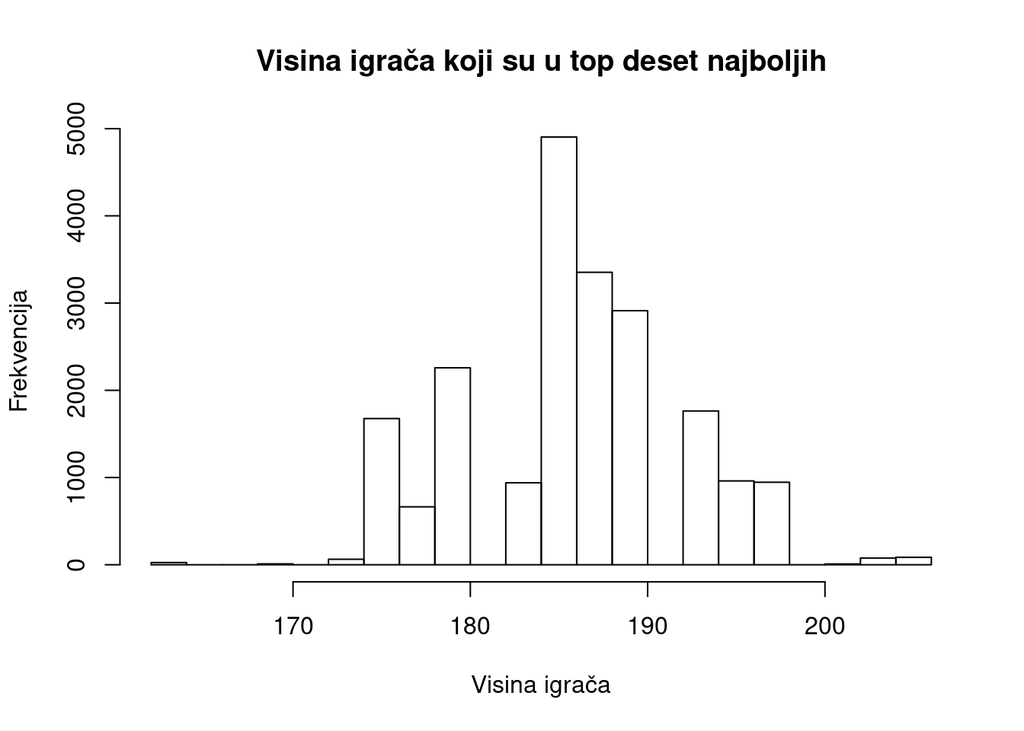

```r
hist(topTenHeight,  xlab="Visina igrača", ylab="Frekvencija", main="Visina igrača koji su u top deset najboljih")
```

```r
# Spremanje visina igrača koji u trenutku igranja meča nisu u top deset najboljih
notTopTenWinnerHeight = tennisMatches[tennisMatches$winner_rank > 10, ]$winner_ht
noTopTenLosserHeight = tennisMatches[tennisMatches$loser_rank > 10, ]$loser_ht

notTopTenHeight = append(notTopTenWinnerHeight, noTopTenLosserHeight)

# Odbacivanje nedostajećih vrijednosti
notTopTenHeight = notTopTenHeight[complete.cases(notTopTenHeight)]
summary(notTopTenHeight)
```

```
##    Min. 1st Qu.  Median    Mean 3rd Qu.    Max.
##   160.0   180.0   185.0   185.2   190.0   211.0
```

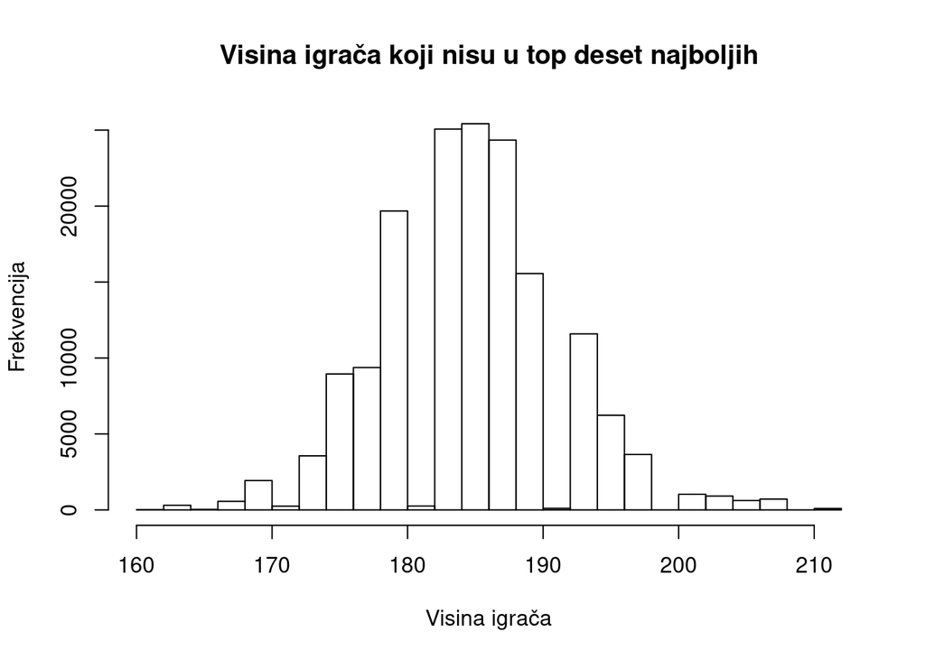

```r
hist(notTopTenHeight, xlab="Visina igrača", ylab="Frekvencija", main="Visina igrača koji nisu u top deset najboljih")
```

Prije određivanja testa potrebno je provjeriti normalnost podataka.

# Histogram te QQ-dijagram upućuju na normalnost podataka visine top deset najboljih igrača.

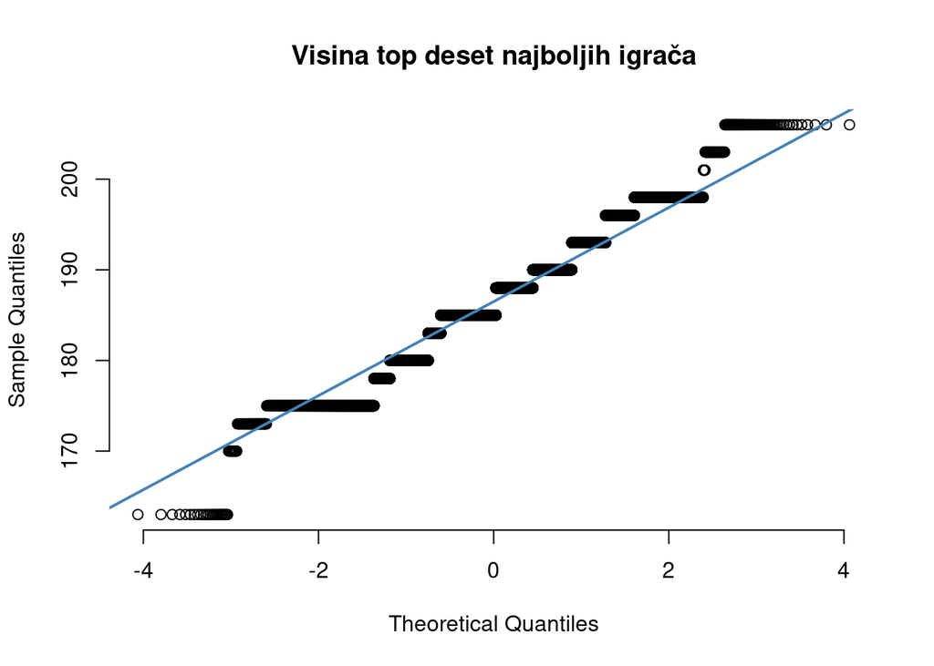

```r
# QQ-dijagram
qqnorm(topTenHeight, pch = 1, frame=FALSE, main="Visina top deset najboljih igrača")
qqline(topTenHeight, col="steelblue", lwd=2)
```

Histogram te QQ-dijagram upućuju na normalnost podataka visine igrača koji nisu u top deset najboljih.

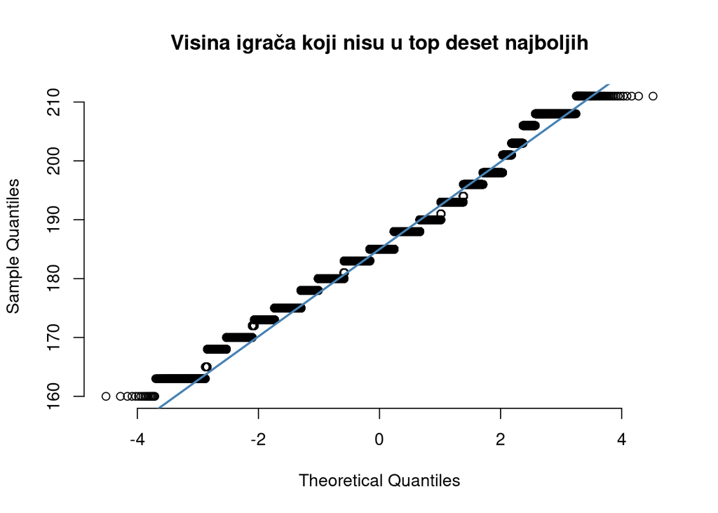

```r
# QQ-dijagram
qqnorm(notTopTenHeight, pch = 1, frame=FALSE, main="Visina igrača koji nisu u top deset najboljih")
qqline(notTopTenHeight, col="steelblue", lwd=2)
```

Pod pretpostavkom da visine igrača prate normalnu distribuciju nastavlja testiranje povezanosti visine i uspješnosti igrača, koristi se t-test.

Testira se postoji li značajna razlika u očekivanju visine igrača koji su u top deset najboljih te onih koji nisu.

$H_0$: očekivanje visine igrača koji su u top deset najboljih je jednako očekivanju visine onih igrača koji nisu top deset najboljih $H_1$: očekivanje visine igrača koji su u top deset najboljih je veće od očekivanja visine onih igrača koji nisu u top deset najboljih

## Provedba t-testa

### Provjera jednakosti varijanci

```r
varTopTen = var(topTenHeight)
varNotTopTen = var(notTopTenHeight)
cat('Varijanca top deset najboljih igrača: ', varTopTen, '\n')
```

```
## Varijanca top deset najboljih igrača:  38.77018
```

```r
cat('Varijanca igrača izvan top deset najboljih: ', varNotTopTen)
```

```
## Varijanca igrača izvan top deset najboljih:  45.34102
```

### Test o jednakosti varijanci

Ako imamo dva nezavisna slučajna uzorka $X_1^1, X_1^2, \ldots X_1^{n_1}$ i $X_2^1, X_2^2, \ldots, X_2^{n_2}$ koji dolaze iz normalnih distribucija s varijancama $\sigma_1^2$ i $\sigma_2^2$, tada slučajna varijabla
$$F = \frac{S_{X_1}^2 / \sigma_1^2}{S_{X_2}^2 / \sigma_2^2}$$

ima Fisherovu distribuciju s $(n_1 - 1, n_2 - 1)$ stupnjeva slobode, pri čemu vrijedi:
$$S_{X_1}^2 = \frac{1}{n_1 - 1} \sum_{i = 1}^{n_1} (X_1^i - \bar{X}_1)^2, \quad S_{X_2}^2 = \frac{1}{n_2 - 1} \sum_{i = 1}^{n_2} (X_2^i - \bar{X}_2)^2.$$
Hipoteze testa jednakosti varijanci glase:
$$\begin{aligned}
H_0&: \sigma_1^2 = \sigma_2^2 \\
H_1&: \sigma_1^2 \neq \sigma_2^2
\end{aligned}$$

```r
var.test(topTenHeight, notTopTenHeight)
```

```
##
##  F test to compare two variances
##
## data:  topTenHeight and notTopTenHeight
## F = 0.85508, num df = 20647, denom df = 160241, p-value < 2.2e-16
## alternative hypothesis: true ratio of variances is not equal to 1
## 95 percent confidence interval:
##  0.8378014 0.8728576
## sample estimates:
## ratio of variances
##          0.8550796
```

### Zaključak

Odbacujemo hipotezu $H_0$ o jednakosti varijanci pri razini značajnosti od 0.05 s obzirom da je p-vrijednost 2.2e-16.

Provedba t-testa uz pretpostavku o nejednakosti varijanci.

```r
t.test(topTenHeight, notTopTenHeight, alt = "greater", var.equal = FALSE)
```

```
##
##  Welch Two Sample t-test
##
## data:  topTenHeight and notTopTenHeight
## t = 26.343, df = 27259, p-value < 2.2e-16
## alternative hypothesis: true difference in means is greater than 0
## 95 percent confidence interval:
##  1.148039      Inf
## sample estimates:
## mean of x mean of y
##  186.3996  185.1751
```

### Zaključak

Na razini značajnosti od 0.05 odbacujemo hipotezu $H_0$ premda je p-vrijednost 2.2e-16, postoji značajna razlika visina igrača u top deset najboljih u posljednjih 30 godina i onih izvan top deset najboljih. Visina igrača u top deset najboljih je veća od visine igrača koji nisu u top deset najboljih.

Iz provedenog testa ne možemo zaključiti da visina izravno utječe na uspješnost igrača, već samo korelaciju između visine i uspješnosti igrača.

## Problem 2

Predviđa li pobjeda prvog seta pobjedu cijelog meča?

Potrebno je izdvojiti sve mečeve u kojima je pobijedio onaj tenisač koji je pobijedio i prvi set.

Podaci o setovima mogu sadržavati W/O koji označuju predaju ili diskvalifikaciju, pa te takve podatke potrebno ukloniti iz skupa podataka.

```r
# Uklanjanje mečeva kojima je score W/O
tennisMatchesSet = tennisMatches[!is.na(as.numeric(substr(tennisMatches$score, 1, 1))), ]
wonFirstSetAndMatchMatches = tennisMatchesSet[substr(tennisMatchesSet$score, 1, 1) > substr(tennisMatchesSet$score, 3, 3), ]

# Mečevi u kojima je pobjednik onaj koji je pobijedio prvi set
wonFirstSetAndMatchCount = dim(wonFirstSetAndMatchMatches)[1]

lostFirstSetAnWonMatchMatches = tennisMatchesSet[substr(tennisMatchesSet$score, 1, 1) < substr(tennisMatchesSet$score, 3, 3), ]

# Mečevi u kojima je pobjednik onaj koji nije pobijedio prvi set
lostFirstSetAndWonMatchCount = dim(lostFirstSetAnWonMatchMatches)[1]
```

## Problem 3

Možemo li temeljem danih varijabli predvidjeti pobjednika teniskog meča?

## Problem 4

Utječe li broj aseva na ishod pobjednika?

### Provjera normalnosti podataka

Provjeravam uparene podatke broja aseva igrača koji je pobijedio (W) umanjene za broj aseva koje je ostvario igrač koji je izgubio (L).

```r
aseviUpareni = c(tennisMatches$w_ace - tennisMatches$l_ace)
```

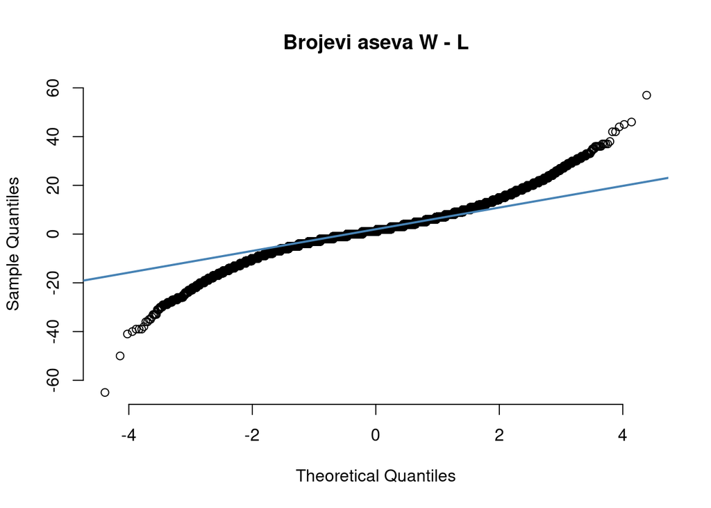

```r
qqnorm(aseviUpareni, pch = 1, frame=FALSE, main="Brojevi aseva W - L")
qqline(aseviUpareni, col="steelblue", lwd=2)
```

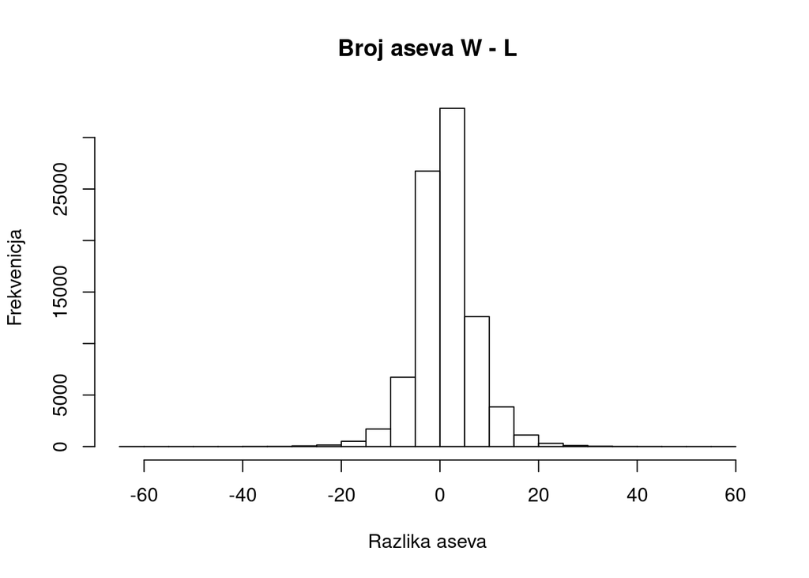

```r
hist(aseviUpareni, main="Broj aseva W - L", xlab = "Razlika aseva", ylab = "Frekvenicja")
```

Podatci prate zvonikoliku krivulju, a t-test je robustan na ne normalnost.

```r
summary(aseviUpareni)
```

```
##    Min. 1st Qu.  Median    Mean 3rd Qu.    Max.    NA's
## -65.000  -1.000   1.000   1.687   5.000  57.000    9793
```

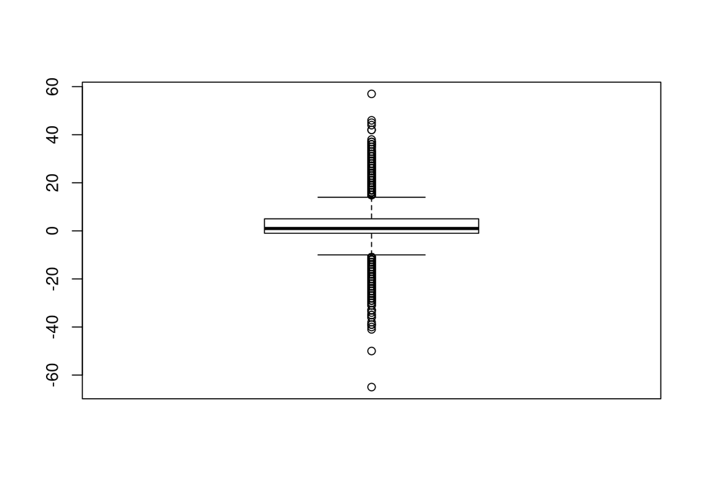

```r
boxplot(aseviUpareni)
```

T test nije pogodan za distribucije s teškim repovima.

Hipoteze: $H_0: \mu_w - \mu_l = 0$ $H_1: \mu_w - \mu_l > 0$

```r
#Provedba t testa
t.test(aseviUpareni, alt="greater")
```

```
##
##  One Sample t-test
##
## data:  aseviUpareni
## t = 84.944, df = 86808, p-value < 2.2e-16
## alternative hypothesis: true mean is greater than 0
## 95 percent confidence interval:
##  1.653928      Inf
## sample estimates:
## mean of x
##  1.686588
```

Zbog male p-vrijednosti možemo zaključiti da broj ostvarenih aseva utječe na pobjedu u meču.

#### Jackknife

```r
aseviUpareni <- na.omit(aseviUpareni)

mx <- mean(aseviUpareni)
ps <- numeric(length(aseviUpareni))
n <- length(aseviUpareni)
for(i in 1:length(aseviUpareni)){
  ps[i] = n * mx - (n-1) * mean(c(aseviUpareni[-i]))
}
se <- sd(ps)/sqrt(n)
j <- mean(ps)
cat("Interval povjerenja od 99% za aritmetičku sredinu je [", (j - qt(0.995, n-1)*se), " ,", (j + qt(0.995, n-1)*se), "]")
```

```
## Interval povjerenja od 99% za aritmetičku sredinu je [ 1.635443  , 1.737733 ]
```

Zato što srednja vrijednost $\mu = 0$ nije unutar 99% intervala procjene uzorka, zaključujem da mogu odbaciti hipotezu $H_0$.